# Forecasting

Tejus

15/11/2020

### What is different?

- Data are dependent over time
- Specific pattern types
  - Trends - long term increase or decrease
  - Seasonal patterns - patterns related to time of week, month, year, etc.
  - Cycles - patterns that rise and fall periodically
- Subsampling into training/test is more complicated
- Similar issues arise in spatial data
  - Dependency between nearby observations
  - Location specific effects
- Typically goal is to predict one or more observations into the future.
- All standard predictions can be used (with caution!)

#### Things to remember

- Beware spurious correlations!
- Beware extrapolation!

### Forecasting with Yahoo data

```r
from.dat <- as.Date("01/01/08", format="%m/%d/%y")
to.dat <- as.Date("12/31/13", format="%m/%d/%y")
getSymbols("GOOG", src="yahoo", from = from.dat, to = to.dat)
```

[output not shown]

```
## [1] "GOOG"
```

```r
head(GOOG)
```

```
##            GOOG.Open GOOG.High GOOG.Low GOOG.Close GOOG.Volume GOOG.Adjusted
## 2008-01-02  345.1413  347.3829 337.5996   341.3157     8646000      341.3157
## 2008-01-03  341.3505  342.1426 336.9969   341.3854     6529300      341.3854
## 2008-01-04  338.5759  339.2086 326.2770   327.2733    10759700      327.2733
## 2008-01-07  325.7490  329.9034 317.4850   323.4128    12854700      323.4128
## 2008-01-08  325.2808  328.7478 314.3218   314.6606    10718100      314.6606
## 2008-01-09  313.8436  325.4501 310.0927   325.3804    13529800      325.3804
```

- Summarise

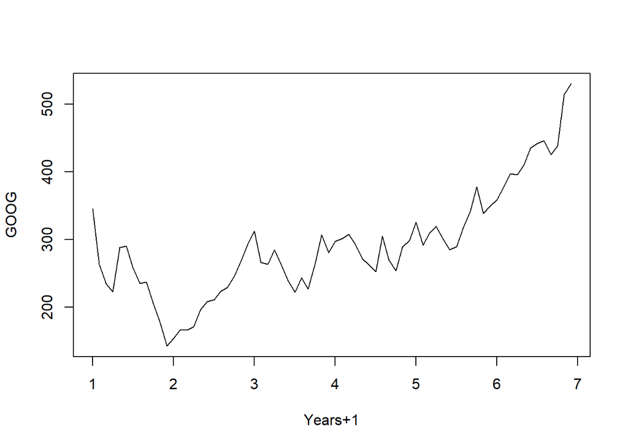

```r
mGoog <- to.monthly(GOOG)
googOpen <- Op(mGoog)
ts1 <- ts(googOpen,frequency=12)
plot(ts1,xlab="Years+1", ylab="GOOG")
```

#### Examples of time series decomposition

- **Trend** - Consistently increasing pattern over time
- **Seasonal** - When there is a pattern over a fixed period of time that recurs.
- **Cyclic** - When data rises and falls over non fixed periods

[Otexts](https://www.otexts.org/fpp/6/1)

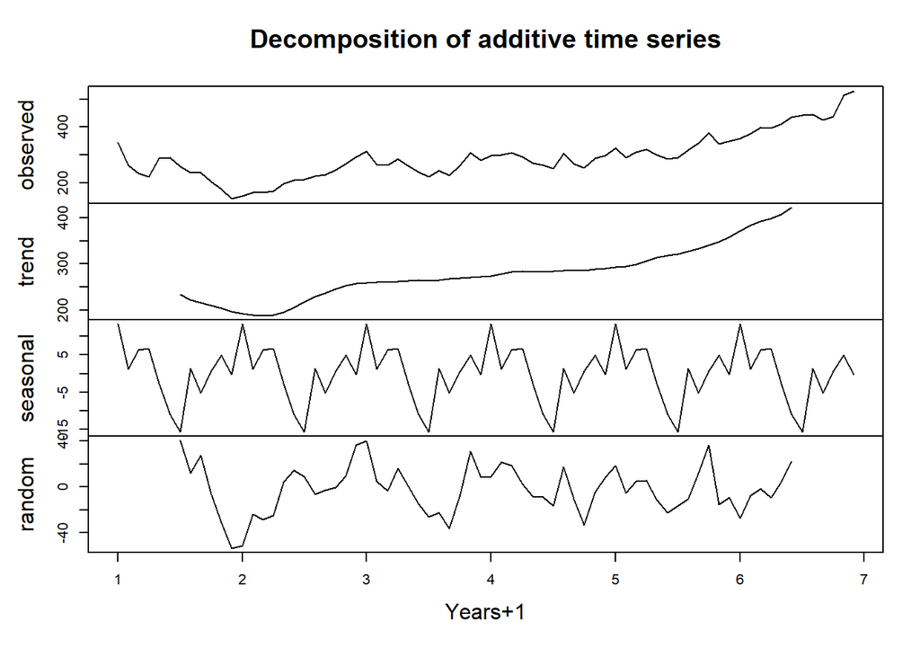

```r
plot(decompose(ts1),xlab="Years+1")
```

#### Training and test sets

- Have to build sets with consecutive time points

```r
ts1Train <- window(ts1,start=1,end=5)
ts1Test <- window(ts1,start=5,end=(7-0.01))
ts1Train
```

```
##        Jan      Feb      Mar      Apr      May      Jun      Jul      Aug
## 1 345.1413 263.3479 234.8746 223.0340 288.0752 290.1624 258.8199 235.3728
## 2 153.7238 166.5208 166.0426 171.2481 196.7774 208.5832 211.3080 223.5322
## 3 312.3044 266.3018 263.6119 284.6082 262.2670 239.3180 221.8136 243.5820
## 4 297.1263 301.1163 307.7365 293.2807 271.8311 263.0341 252.4239 304.4688
## 5 325.2509
##        Sep      Oct      Nov      Dec
## 1 237.4948 204.8073 178.1224 142.8047
## 2 228.9817 245.5795 267.5372 292.9669
## 3 226.6405 264.0104 306.7154 280.4488
## 4 269.3654 253.9731 288.9669 298.8797
## 5
```

### Forecasting with simple moving average

$$Y_{t}=\frac{1}{2*k+1}\sum_{j=-k}^k {y_{t+j}}$$

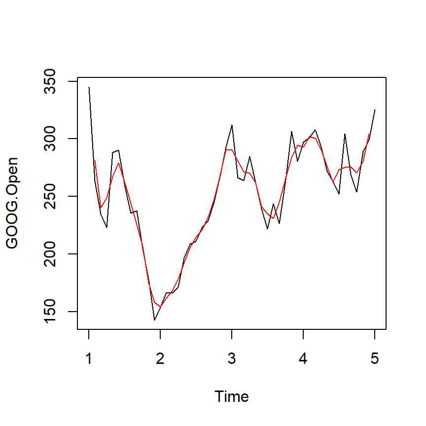

```r
plot(ts1Train)
lines(ma(ts1Train,order=3),col="red")
```

- Prediction will be an average of the previous time points out to a particular time.

### Exponential smoothing

- Weight nearby time points with higher values than those that are far.

**Example - simple exponential smoothing**
$$\hat{y}_{t+1} = \alpha y_t + (1-\alpha)\hat{y}_{t-1}$$

- Different classes to choose from

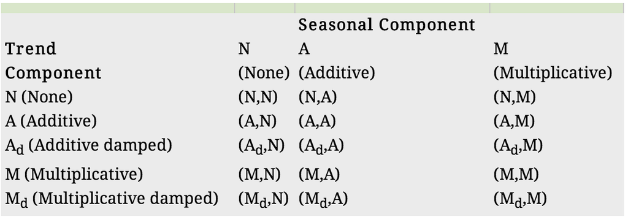

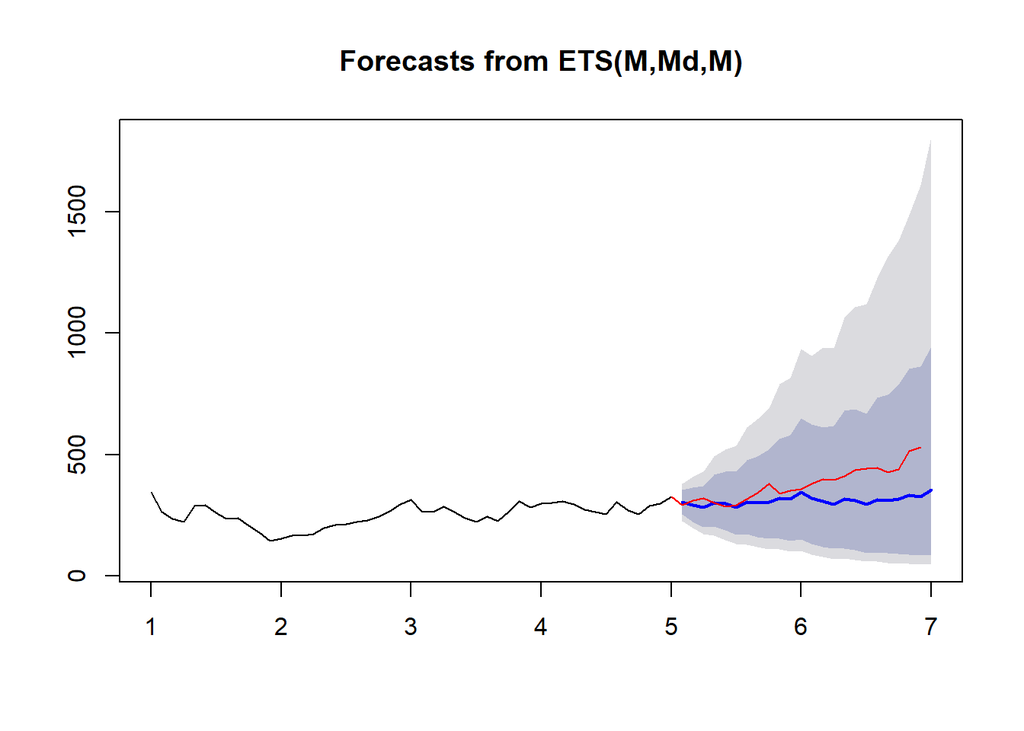

```r
ets1 <- ets(ts1Train,model="MMM")
fcast <- forecast(ets1)
# You get prediction bounds also
plot(fcast); lines(ts1Test,col="red")
```

```r
## For Accuracy
accuracy(fcast,ts1Test)
```

```
##                      ME     RMSE      MAE        MPE      MAPE      MASE
## Training set  0.2000302 26.09189 20.65928 -0.3572633  8.302526 0.3933832
## Test set     69.8911746 93.08104 72.04076 16.2879469 17.032408 1.3717625
##                       ACF1 Theil's U
## Training set -0.0002846501        NA
## Test set      0.7575349604  3.375609
```

### Notes and further resources

- [Forecasting and timeseries prediction](http://en.wikipedia.org/wiki/Forecasting) is an entire field
- Rob Hyndman’s [Forecasting: principles and practice](https://www.otexts.org/fpp/) is a good place to start
- Cautions
  - Be wary of spurious correlations
  - Be careful how far you predict (extrapolation)
  - Be wary of dependencies over time
- See [quantmod](http://cran.r-project.org/web/packages/quantmod/quantmod.pdf) or [quandl](http://www.quandl.com/help/packages/r) packages for finance-related problems.